# Лабораторна робота №2. Розвідувальний аналіз даних.

**Мета:** *Засвоєння принципів, знайомство з інструментами та набуття навичок експлораторного (розвідувального) аналізу даних засобами мови програмування R та колекції пакетів dplyr, ggplot2, desctable, “GGally”, “corrplot”, “PerformanceAnalytics”, “FactoMineR”, “factoextra”, “funModeling”, “desctable”, “ade4”, “psych”, “smacof”, “WVPlots”, “caret”, “car”.*.

## 1 Хід роботи

Об’єктом дослідження є вбудований датасет `CO2`, що містить результати експерименту з холодостійкості рослин виду *Echinochloa crus-galli*. Набір даних включає 84 спостереження та 5 змінних (факторні та числові).

Основні питання дослідження: 1. Оцінити якість та розподіл даних. 2. Визначити наявність кореляції між концентрацією `CO2` та поглинанням. 3. Виконати PCA для числових змінних та спробувати знайти паттерни (кластери) серед рослин різного походження.

### 1.1 Підготовка та первинний огляд даних

Завантажимо необхідні бібліотеки та сам датасет.

```r
library(tidyverse)
library(corrplot)
library(FactoMineR)
library(factoextra)

data(CO2)
eco_data <- as_tibble(CO2)

head(eco_data)
```

| Plant | Type | Treatment | conc | uptake |
| --- | --- | --- | --- | --- |
| Qn1 | Quebec | nonchilled | 95 | 16.0 |
| Qn1 | Quebec | nonchilled | 175 | 30.4 |
| Qn1 | Quebec | nonchilled | 250 | 34.8 |
| Qn1 | Quebec | nonchilled | 350 | 37.2 |
| Qn1 | Quebec | nonchilled | 500 | 35.3 |
| Qn1 | Quebec | nonchilled | 675 | 39.2 |

Переглянемо структуру даних та основні статистичні показники.

```r
glimpse(eco_data)
```

```
Rows: 84
Columns: 5
$ Plant     <ord> Qn1, Qn1, Qn1, Qn1, Qn1, Qn1, Qn1, Qn2, Qn2, Qn2, Qn2, Qn2, Qn2, Q…
$ Type      <fct> Quebec, Quebec, Quebec, Quebec, Quebec, Quebec, Quebec, Quebec, Qu…
$ Treatment <fct> nonchilled, nonchilled, nonchilled, nonchilled, nonchilled, nonchi…
$ conc      <dbl> 95, 175, 250, 350, 500, 675, 1000, 95, 175, 250, 350, 500, 675, 10…
$ uptake    <dbl> 16.0, 30.4, 34.8, 37.2, 35.3, 39.2, 39.7, 13.6, 27.3, 37.1, 41.8, …
```

```r
summary(eco_data)
```

```
     Plant             Type         Treatment       conc          uptake
 Qn1    : 7   Quebec     :42   nonchilled:42   Min.   :  95   Min.   : 7.70
 Qn2    : 7   Mississippi:42   chilled   :42   1st Qu.: 175   1st Qu.:17.90
 Qn3    : 7                                    Median : 350   Median :28.30
 Qc1    : 7                                    Mean   : 435   Mean   :27.21
 Qc3    : 7                                    3rd Qu.: 675   3rd Qu.:37.12
 Qc2    : 7                                    Max.   :1000   Max.   :45.50
 (Other):42
```

## 2 Аналіз описової статистики:

**Комплектність**: Пропущених значень (NA) немає. Датасет повний.

**Типи даних**: Маємо 3 категоріальні змінні (Plant, Type, Treatment) та 2 числові (conc, uptake).

**Діапазони**:

**conc** (концентрація `CO2`) варіюється від 95 до 1000 мл/л. **uptake** (поглинання) варіюється від 7.7 до 45.5 мкмоль/м²с.

**Аномалії**: Нульові або від’ємні значення відсутні, що є логічним для фізичних вимірювань у цьому експерименті.

## 3 Аналіз розподілу змінних

Побудуємо графіки щільності розподілу для числових змінних, щоб зрозуміти їхню природу.

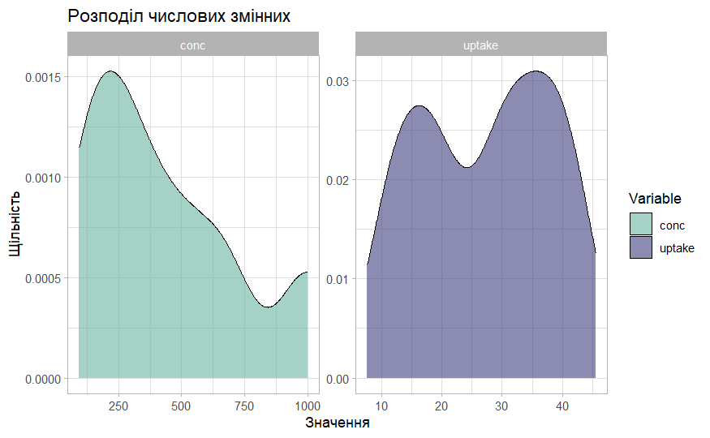

```r
eco_data |>
  select(conc, uptake) |>
  pivot_longer(cols = everything(), names_to = "Variable", values_to = "Value") |>
  ggplot(aes(x = Value, fill = Variable)) +
  geom_density(alpha = 0.6, color = "black") +
  facet_wrap(~Variable, scales = "free") +
  scale_fill_manual(values = c("conc" = "#69b3a2", "uptake" = "#404080")) +
  theme_light() +
  labs(title = "Розподіл числових змінних", y = "Щільність", x = "Значення")
```

Що ми бачимо?

**1.** Розподіл `conc` є мультимодальним (має кілька піків). Це пояснюється дизайном експерименту: концентрація подавалася дискретними рівнями (95, 175, 250 і т.д.), а не була випадковою величиною.

## 4 Аналіз кореляцій

Перевіримо, чи існує лінійний зв’язок між концентрацією вуглекислого газу та швидкістю його поглинання.

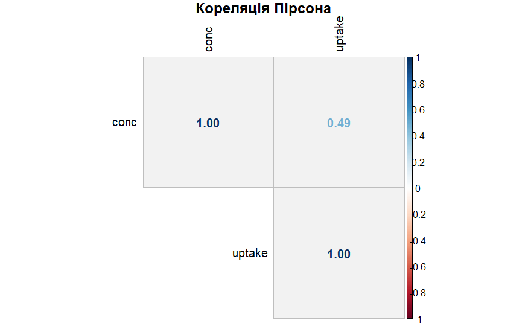

```r
cor_matrix <- cor(eco_data |> select(where(is.numeric)))

corrplot(cor_matrix, method = "number", type = "upper",
         tl.col = "black", bg = "grey95", title = "Кореляція Пірсона", mar=c(0,0,1,0))
```

Висновки щодо кореляції: Коефіцієнт кореляції між `conc` та `uptake` становить 0.49. Це середній позитивний зв’язок. Тобто, зі збільшенням концентрації `CO2` поглинання зростає, але цей зв’язок не є ідеально лінійним (можливо, настає ефект насичення).

Щоб глибше зрозуміти природу даних, побудуємо діаграму розсіювання з розділенням за походженням рослин (`Type`).

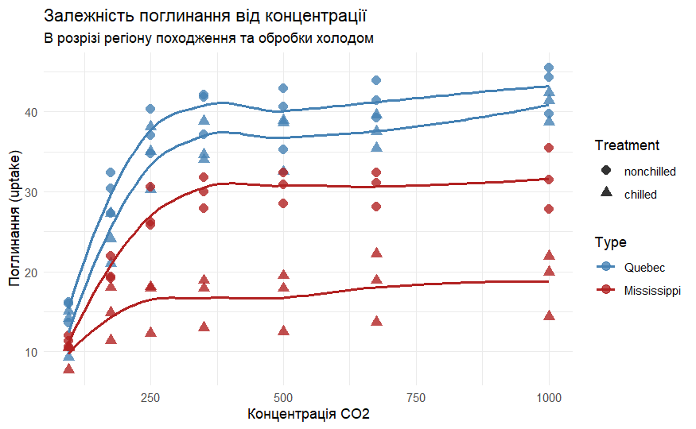

```r
ggplot(eco_data, aes(x = conc, y = uptake, color = Type, shape = Treatment)) +
  geom_point(size = 3, alpha = 0.8) +
  geom_smooth(method = "loess", se = FALSE, size = 1) +
  scale_color_manual(values = c("Quebec" = "steelblue", "Mississippi" = "firebrick")) +
  theme_minimal() +
  labs(title = "Залежність поглинання від концентрації",
       subtitle = "В розрізі регіону походження та обробки холодом",
       x = "Концентрація CO2", y = "Поглинання (uptake)")
```

На графіку чітко видно, що рослини з Квебеку (сині) загалом мають вищий рівень поглинання, ніж рослини з Міссісіпі (червоні), особливо при високих концентраціях.